# **`CASE STUDY - 1` :: Healthcare Provider Fraudulent Detection**

### **Q13. Lets see the number of beneficiaries on the basis of 'ChronicCond_ObstrPulmonary'. And, the Annual IP & OP expenditures for such patients.**

```python
# Number of beneficiaries with chronic or no-chronic conditions
pd.DataFrame(train_bene_df.groupby(['ChronicCond_ObstrPulmonary'])['BeneID'].count())
```

| ChronicCond_ObstrPulmonary | BeneID |
| --- | --- |
| 1 | 32859 |
| 2 | 105697 |

```python
CC_PL_IP_R = pd.DataFrame(train_bene_df.groupby(['ChronicCond_ObstrPulmonary'])['IPAnnualReimbursementAmt'].sum() / train_bene_df.groupby(['ChronicCond_ObstrPulmonary'])['BeneID'].count())
CC_PL_IP_R.columns = ['AVG IP Reimbursement Amt']
CC_PL_IP_R
```

| ChronicCond_ObstrPulmonary | AVG IP Reimbursement Amt |
| --- | --- |
| 1 | 7361.772422 |
| 2 | 2509.650132 |

```python
CC_PL_OP_R = pd.DataFrame(train_bene_df.groupby(['ChronicCond_ObstrPulmonary'])['OPAnnualReimbursementAmt'].sum() / train_bene_df.groupby(['ChronicCond_ObstrPulmonary'])['BeneID'].count())
CC_PL_OP_R.columns = ['AVG OP Reimbursement Amt']
CC_PL_OP_R
```

| ChronicCond_ObstrPulmonary | AVG OP Reimbursement Amt |
| --- | --- |
| 1 | 1810.864908 |
| 2 | 1138.848501 |

```python
CC_PL_IP_D = pd.DataFrame(train_bene_df.groupby(['ChronicCond_ObstrPulmonary'])['IPAnnualDeductibleAmt'].sum() / train_bene_df.groupby(['ChronicCond_ObstrPulmonary'])['BeneID'].count())
CC_PL_IP_D.columns = ['AVG IP Co-payment Amt']
CC_PL_IP_D
```

| ChronicCond_ObstrPulmonary | AVG IP Co-payment Amt |
| --- | --- |
| 1 | 818.228917 |
| 2 | 269.781148 |

```python
CC_PL_OP_D = pd.DataFrame(train_bene_df.groupby(['ChronicCond_ObstrPulmonary'])['OPAnnualDeductibleAmt'].sum() / train_bene_df.groupby(['ChronicCond_ObstrPulmonary'])['BeneID'].count())
CC_PL_OP_D.columns = ['AVG OP Co-payment Amt']
CC_PL_OP_D
```

| ChronicCond_ObstrPulmonary | AVG OP Co-payment Amt |
| --- | --- |
| 1 | 519.44767 |
| 2 | 333.65753 |

```python
CC_PL_all_amts = pd.concat([CC_PL_IP_R, CC_PL_OP_R, CC_PL_IP_D, CC_PL_OP_D], axis=1)
CC_PL_all_amts
```

| ChronicCond_ObstrPulmonary | AVG IP Reimbursement Amt | AVG OP Reimbursement Amt | AVG IP Co-payment Amt | AVG OP Co-payment Amt |
| --- | --- | --- | --- | --- |
| 1 | 7361.772422 | 1810.864908 | 818.228917 | 519.44767 |
| 2 | 2509.650132 | 1138.848501 | 269.781148 | 333.65753 |

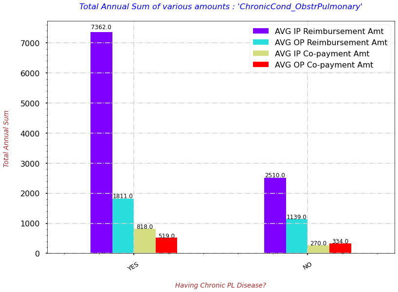

```python
# Here, I'm displaying the Total Annual Sum of IP Co-payment for 'ChronicCond_ObstrPulmonary'
with plt.style.context('seaborn-poster'):
  fig = CC_PL_all_amts.plot(kind='bar', colormap='rainbow')
  # Using the "patches" function we will get the location of the rectangle bars from the graph.
  ## Then by using those location(width & height) values we will add the annotations
  for p in fig.patches:
    width = p.get_width()
    height = p.get_height()
    x, y = p.get_xy()
    fig.annotate(f'{round(height,0)}', (x + width/2, y + height*1.015), ha='center', fontsize=12, rotation=0)
  # Providing the labels and title to the graph
  plt.xlabel("\nHaving Chronic PL Disease?", fontdict=label_font_dict)
  plt.xticks(ticks=[0,1], labels=['YES', 'NO'], fontsize=13, rotation=30)
  plt.ylabel("Total Annual Sum \n", fontdict=label_font_dict)
  plt.grid(which='major', linestyle="-.", color='lightgrey')
  plt.minorticks_on()
  plt.title("Total Annual Sum of various amounts : 'ChronicCond_ObstrPulmonary'\n", fontdict=title_font_dict)

# 1 means +ve with Chronic PL Disease
# 2 means -ve with Chronic PL Disease
```

- **`OBSERVATION`**
  - The above graph is telling us below points:
    - Payer pays huge chunk of expenses specially when a beneficiary gets admitted with or without chronic HF disease. To be more precise, in case of +ve it is more than 50%.
    - For other comparisons the difference is not very high.

### **Q14. Lets see the number of beneficiaries on the basis of 'ChronicCond_Depression'. And, the Annual IP & OP expenditures for such patients.**

```python
# Number of beneficiaries with chronic or no-chronic conditions
pd.DataFrame(train_bene_df.groupby(['ChronicCond_Depression'])['BeneID'].count())
```

| ChronicCond_Depression | BeneID |
| --- | --- |
| 1 | 49260 |
| 2 | 89296 |

```python
CC_DP_IP_R = pd.DataFrame(train_bene_df.groupby(['ChronicCond_Depression'])['IPAnnualReimbursementAmt'].sum() / train_bene_df.groupby(['ChronicCond_Depression'])['BeneID'].count())
CC_DP_IP_R.columns = ['AVG IP Reimbursement Amt']
CC_DP_IP_R
```

| ChronicCond_Depression | AVG IP Reimbursement Amt |
| --- | --- |
| 1 | 5022.162810 |
| 2 | 2909.102647 |

```python
CC_DP_OP_R = pd.DataFrame(train_bene_df.groupby(['ChronicCond_Depression'])['OPAnnualReimbursementAmt'].sum() / train_bene_df.groupby(['ChronicCond_Depression'])['BeneID'].count())
CC_DP_OP_R.columns = ['AVG OP Reimbursement Amt']
CC_DP_OP_R
```

| ChronicCond_Depression | AVG OP Reimbursement Amt |
| --- | --- |
| 1 | 1603.871701 |
| 2 | 1129.606701 |

```python
CC_DP_IP_D = pd.DataFrame(train_bene_df.groupby(['ChronicCond_Depression'])['IPAnnualDeductibleAmt'].sum() / train_bene_df.groupby(['ChronicCond_Depression'])['BeneID'].count())
CC_DP_IP_D.columns = ['AVG IP Co-payment Amt']
CC_DP_IP_D
```

| ChronicCond_Depression | AVG IP Co-payment Amt |
| --- | --- |
| 1 | 570.054771 |
| 2 | 305.952607 |

```python
CC_DP_OP_D = pd.DataFrame(train_bene_df.groupby(['ChronicCond_Depression'])['OPAnnualDeductibleAmt'].sum() / train_bene_df.groupby(['ChronicCond_Depression'])['BeneID'].count())
CC_DP_OP_D.columns = ['AVG OP Co-payment Amt']
CC_DP_OP_D
```

| ChronicCond_Depression | AVG OP Co-payment Amt |
| --- | --- |
| 1 | 464.285708 |
| 2 | 329.963459 |

```python
CC_DP_all_amts = pd.concat([CC_DP_IP_R, CC_DP_OP_R, CC_DP_IP_D, CC_DP_OP_D], axis=1)
CC_DP_all_amts
```

| ChronicCond_Depression | AVG IP Reimbursement Amt | AVG OP Reimbursement Amt | AVG IP Co-payment Amt | AVG OP Co-payment Amt |
| --- | --- | --- | --- | --- |
| 1 | 5022.162810 | 1603.871701 | 570.054771 | 464.285708 |
| 2 | 2909.102647 | 1129.606701 | 305.952607 | 329.963459 |

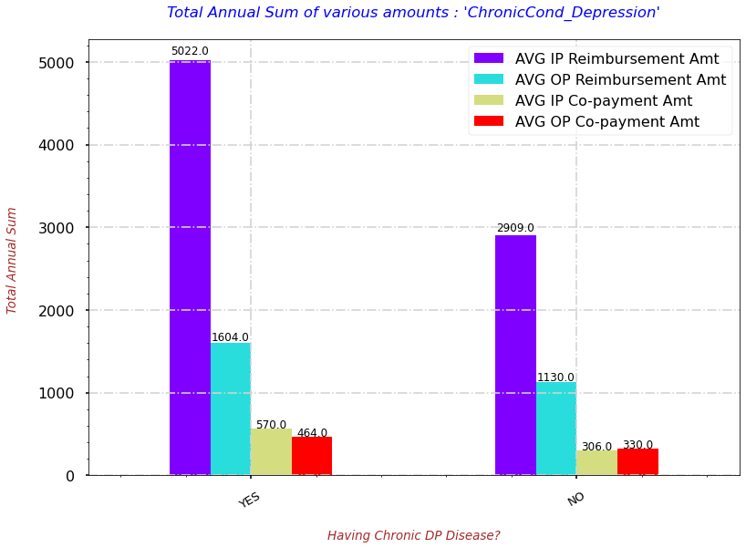

```python
# Here, I'm displaying the Total Annual Sum of IP Co-payment for 'ChronicCond_Depression'
with plt.style.context('seaborn-poster'):
  fig = CC_DP_all_amts.plot(kind='bar', colormap='rainbow')
  # Using the "patches" function we will get the location of the rectangle bars from the graph.
  ## Then by using those location(width & height) values we will add the annotations
  for p in fig.patches:
    width = p.get_width()
    height = p.get_height()
    x, y = p.get_xy()
    fig.annotate(f'{round(height,0)}', (x + width/2, y + height*1.015), ha='center', fontsize=12, rotation=0)
  # Providing the labels and title to the graph
  plt.xlabel("\nHaving Chronic DP Disease?", fontdict=label_font_dict)
  plt.xticks(ticks=[0,1], labels=['YES', 'NO'], fontsize=13, rotation=30)
  plt.ylabel("Total Annual Sum \n", fontdict=label_font_dict)
  plt.grid(which='major', linestyle="-.", color='lightgrey')
  plt.minorticks_on()
  plt.title("Total Annual Sum of various amounts : 'ChronicCond_Depression'\n", fontdict=title_font_dict)

# 1 means +ve with Chronic DP Disease
# 2 means -ve with Chronic DP Disease
```

- **`OBSERVATION`**
  - The above graph is telling us below points:
    - Payer pays huge chunk of expenses specially when a beneficiary gets admitted with or without chronic HF disease. To be more precise, in case of +ve it is around 42%.
    - For other comparisons the difference is not very high.

### **Q15. Lets see the number of beneficiaries on the basis of 'ChronicCond_Diabetes'. And, the Annual IP & OP expenditures for such patients.**

```python
# Number of beneficiaries with chronic or no-chronic conditions
pd.DataFrame(train_bene_df.groupby(['ChronicCond_Diabetes'])['BeneID'].count())
```

| ChronicCond_Diabetes | BeneID |
| --- | --- |
| 1 | 83391 |
| 2 | 55165 |

```python
CC_DB_IP_R = pd.DataFrame(train_bene_df.groupby(['ChronicCond_Diabetes'])['IPAnnualReimbursementAmt'].sum() / train_bene_df.groupby(['ChronicCond_Diabetes'])['BeneID'].count())
CC_DB_IP_R.columns = ['AVG IP Reimbursement Amt']
CC_DB_IP_R
```

| ChronicCond_Diabetes | AVG IP Reimbursement Amt |
| --- | --- |
| 1 | 4870.622010 |
| 2 | 1830.815372 |

```python
CC_DB_OP_R = pd.DataFrame(train_bene_df.groupby(['ChronicCond_Diabetes'])['OPAnnualReimbursementAmt'].sum() / train_bene_df.groupby(['ChronicCond_Diabetes'])['BeneID'].count())
CC_DB_OP_R.columns = ['AVG OP Reimbursement Amt']
CC_DB_OP_R
```

| ChronicCond_Diabetes | AVG OP Reimbursement Amt |
| --- | --- |
| 1 | 1607.259536 |
| 2 | 831.054110 |

```python
CC_DB_IP_D = pd.DataFrame(train_bene_df.groupby(['ChronicCond_Diabetes'])['IPAnnualDeductibleAmt'].sum() / train_bene_df.groupby(['ChronicCond_Diabetes'])['BeneID'].count())
CC_DB_IP_D.columns = ['AVG IP Co-payment Amt']
CC_DB_IP_D
```

| ChronicCond_Diabetes | AVG IP Co-payment Amt |
| --- | --- |
| 1 | 534.254680 |
| 2 | 196.668359 |

```python
CC_DB_OP_D = pd.DataFrame(train_bene_df.groupby(['ChronicCond_Diabetes'])['OPAnnualDeductibleAmt'].sum() / train_bene_df.groupby(['ChronicCond_Diabetes'])['BeneID'].count())
CC_DB_OP_D.columns = ['AVG OP Co-payment Amt']
CC_DB_OP_D
```

| ChronicCond_Diabetes | AVG OP Co-payment Amt |
| --- | --- |
| 1 | 464.345421 |
| 2 | 246.767008 |

```python
CC_DB_all_amts = pd.concat([CC_DB_IP_R, CC_DB_OP_R, CC_DB_IP_D, CC_DB_OP_D], axis=1)
CC_DB_all_amts
```

| ChronicCond_Diabetes | AVG IP Reimbursement Amt | AVG OP Reimbursement Amt | AVG IP Co-payment Amt | AVG OP Co-payment Amt |
| --- | --- | --- | --- | --- |
| 1 | 4870.622010 | 1607.259536 | 534.254680 | 464.345421 |
| 2 | 1830.815372 | 831.054110 | 196.668359 | 246.767008 |

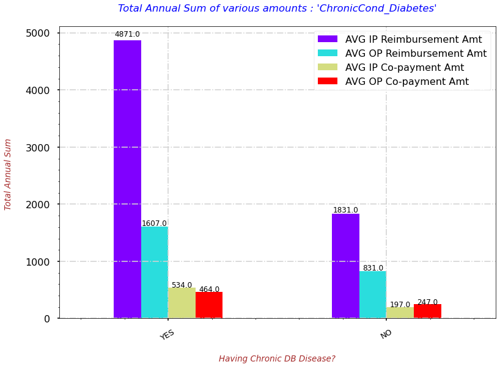

```python
# Here, I'm displaying the Total Annual Sum of IP Co-payment for 'ChronicCond_Diabetes'
with plt.style.context('seaborn-poster'):
  fig = CC_DB_all_amts.plot(kind='bar', colormap='rainbow')
  # Using the "patches" function we will get the location of the rectangle bars from the graph.
  ## Then by using those location(width & height) values we will add the annotations
  for p in fig.patches:
    width = p.get_width()
    height = p.get_height()
    x, y = p.get_xy()
    fig.annotate(f'{round(height,0)}', (x + width/2, y + height*1.015), ha='center', fontsize=12, rotation=0)
  # Providing the labels and title to the graph
  plt.xlabel("\nHaving Chronic DB Disease?", fontdict=label_font_dict)
  plt.xticks(ticks=[0,1], labels=['YES', 'NO'], fontsize=13, rotation=30)
  plt.ylabel("Total Annual Sum \n", fontdict=label_font_dict)
  plt.grid(which='major', linestyle="-.", color='lightgrey')
  plt.minorticks_on()
  plt.title("Total Annual Sum of various amounts : 'ChronicCond_Diabetes'\n", fontdict=title_font_dict)

# 1 means +ve with Chronic DB Disease
# 2 means -ve with Chronic DB Disease
```

- **`OBSERVATION`**
  - The above graph is telling us below points:
    - Payer pays huge chunk of expenses specially when a beneficiary gets admitted with or without chronic HF disease. To be more precise, in case of +ve it is more than 50%.
    - For other comparisons the difference is not very high.

### **Q16. Lets see the number of beneficiaries on the basis of 'ChronicCond_IschemicHeart'. And, the Annual IP & OP expenditures for such patients.**

```python
# Number of beneficiaries with chronic or no-chronic conditions
pd.DataFrame(train_bene_df.groupby(['ChronicCond_IschemicHeart'])['BeneID'].count())
```

| ChronicCond_IschemicHeart | BeneID |
| --- | --- |
| 1 | 93644 |
| 2 | 44912 |

```python
CC_IH_IP_R = pd.DataFrame(train_bene_df.groupby(['ChronicCond_IschemicHeart'])['IPAnnualReimbursementAmt'].sum() / train_bene_df.groupby(['ChronicCond_IschemicHeart'])['BeneID'].count())
CC_IH_IP_R.columns = ['AVG IP Reimbursement Amt']
CC_IH_IP_R
```

| ChronicCond_IschemicHeart | AVG IP Reimbursement Amt |
| --- | --- |
| 1 | 4697.683034 |
| 2 | 1497.442554 |

```python
CC_IH_OP_R = pd.DataFrame(train_bene_df.groupby(['ChronicCond_IschemicHeart'])['OPAnnualReimbursementAmt'].sum() / train_bene_df.groupby(['ChronicCond_IschemicHeart'])['BeneID'].count())
CC_IH_OP_R.columns = ['AVG OP Reimbursement Amt']
CC_IH_OP_R
```

| ChronicCond_IschemicHeart | AVG OP Reimbursement Amt |
| --- | --- |
| 1 | 1521.077485 |
| 2 | 833.547827 |

```python
CC_IH_IP_D = pd.DataFrame(train_bene_df.groupby(['ChronicCond_IschemicHeart'])['IPAnnualDeductibleAmt'].sum() / train_bene_df.groupby(['ChronicCond_IschemicHeart'])['BeneID'].count())
CC_IH_IP_D.columns = ['AVG IP Co-payment Amt']
CC_IH_IP_D
```

| ChronicCond_IschemicHeart | AVG IP Co-payment Amt |
| --- | --- |
| 1 | 506.661676 |
| 2 | 177.133416 |

```python
CC_IH_OP_D = pd.DataFrame(train_bene_df.groupby(['ChronicCond_IschemicHeart'])['OPAnnualDeductibleAmt'].sum() / train_bene_df.groupby(['ChronicCond_IschemicHeart'])['BeneID'].count())
CC_IH_OP_D.columns = ['AVG OP Co-payment Amt']
CC_IH_OP_D
```

| ChronicCond_IschemicHeart | AVG OP Co-payment Amt |
| --- | --- |
| 1 | 441.447535 |
| 2 | 244.839197 |

```python
CC_IH_all_amts = pd.concat([CC_IH_IP_R, CC_IH_OP_R, CC_IH_IP_D, CC_IH_OP_D], axis=1)
CC_IH_all_amts
```

| ChronicCond_IschemicHeart | AVG IP Reimbursement Amt | AVG OP Reimbursement Amt | AVG IP Co-payment Amt | AVG OP Co-payment Amt |
| --- | --- | --- | --- | --- |
| 1 | 4697.683034 | 1521.077485 | 506.661676 | 441.447535 |
| 2 | 1497.442554 | 833.547827 | 177.133416 | 244.839197 |

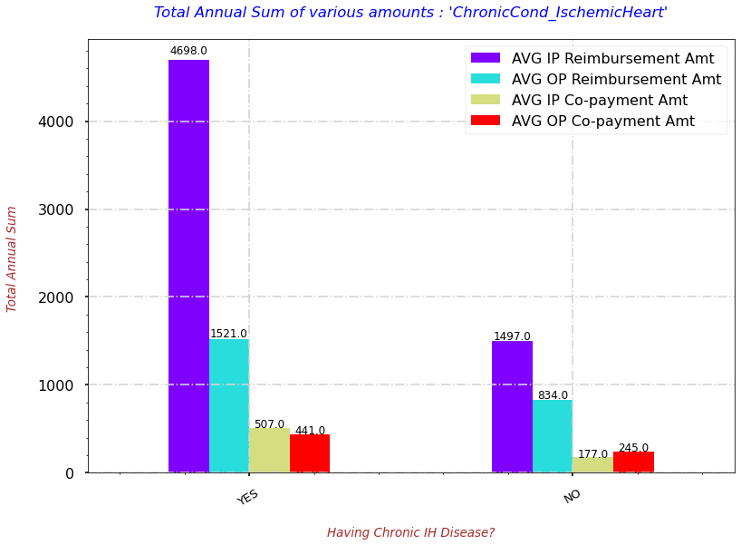

```python
# Here, I'm displaying the Total Annual Sum of IP Co-payment for 'ChronicCond_IschemicHeart'
with plt.style.context('seaborn-poster'):
  fig = CC_IH_all_amts.plot(kind='bar', colormap='rainbow')
  # Using the "patches" function we will get the location of the rectangle bars from the graph.
  ## Then by using those location(width & height) values we will add the annotations
  for p in fig.patches:
    width = p.get_width()
    height = p.get_height()
    x, y = p.get_xy()
    fig.annotate(f'{round(height,0)}', (x + width/2, y + height*1.015), ha='center', fontsize=12, rotation=0)
  # Providing the labels and title to the graph
  plt.xlabel("\nHaving Chronic IH Disease?", fontdict=label_font_dict)
  plt.xticks(ticks=[0,1], labels=['YES', 'NO'], fontsize=13, rotation=30)
  plt.ylabel("Total Annual Sum \n", fontdict=label_font_dict)
  plt.grid(which='major', linestyle="-.", color='lightgrey')
  plt.minorticks_on()
  plt.title("Total Annual Sum of various amounts : 'ChronicCond_IschemicHeart'\n", fontdict=title_font_dict)

# 1 means +ve with Chronic IH Disease
# 2 means -ve with Chronic IH Disease
```

- **`OBSERVATION`**
  - The above graph is telling us below points:
    - Payer pays huge chunk of expenses specially when a beneficiary gets admitted with or without chronic HF disease. To be more precise, in case of +ve it is more than 50%.
    - For other comparisons the difference is not very high.

### **Q17. Lets see the number of beneficiaries on the basis of 'ChronicCond_Osteoporasis'. And, the Annual IP & OP expenditures for such patients.**

```python
# Number of beneficiaries with chronic or no-chronic conditions
pd.DataFrame(train_bene_df.groupby(['ChronicCond_Osteoporasis'])['BeneID'].count())
```

| ChronicCond_Osteoporasis | BeneID |
| --- | --- |
| 1 | 38059 |
| 2 | 100497 |

```python
CC_OS_IP_R = pd.DataFrame(train_bene_df.groupby(['ChronicCond_Osteoporasis'])['IPAnnualReimbursementAmt'].sum() / train_bene_df.groupby(['ChronicCond_Osteoporasis'])['BeneID'].count())
CC_OS_IP_R.columns = ['AVG IP Reimbursement Amt']
CC_OS_IP_R
```

| ChronicCond_Osteoporasis | AVG IP Reimbursement Amt |
| --- | --- |
| 1 | 4608.419822 |
| 2 | 3301.303721 |

```python
CC_OS_OP_R = pd.DataFrame(train_bene_df.groupby(['ChronicCond_Osteoporasis'])['OPAnnualReimbursementAmt'].sum() / train_bene_df.groupby(['ChronicCond_Osteoporasis'])['BeneID'].count())
CC_OS_OP_R.columns = ['AVG OP Reimbursement Amt']
CC_OS_OP_R
```

| ChronicCond_Osteoporasis | AVG OP Reimbursement Amt |
| --- | --- |
| 1 | 1494.709004 |
| 2 | 1223.807178 |

```python
CC_OS_IP_D = pd.DataFrame(train_bene_df.groupby(['ChronicCond_Osteoporasis'])['IPAnnualDeductibleAmt'].sum() / train_bene_df.groupby(['ChronicCond_Osteoporasis'])['BeneID'].count())
CC_OS_IP_D.columns = ['AVG IP Co-payment Amt']
CC_OS_IP_D
```

| ChronicCond_Osteoporasis | AVG IP Co-payment Amt |
| --- | --- |
| 1 | 512.038204 |
| 2 | 357.359722 |

```python
CC_OS_OP_D = pd.DataFrame(train_bene_df.groupby(['ChronicCond_Osteoporasis'])['OPAnnualDeductibleAmt'].sum() / train_bene_df.groupby(['ChronicCond_Osteoporasis'])['BeneID'].count())
CC_OS_OP_D.columns = ['AVG OP Co-payment Amt']
CC_OS_OP_D
```

| ChronicCond_Osteoporasis | AVG OP Co-payment Amt |
| --- | --- |
| 1 | 436.249271 |
| 2 | 355.552106 |

```python
CC_OS_all_amts = pd.concat([CC_OS_IP_R, CC_OS_OP_R, CC_OS_IP_D, CC_OS_OP_D], axis=1)
CC_OS_all_amts
```

| ChronicCond_Osteoporasis | AVG IP Reimbursement Amt | AVG OP Reimbursement Amt | AVG IP Co-payment Amt | AVG OP Co-payment Amt |
| --- | --- | --- | --- | --- |
| 1 | 4608.419822 | 1494.709004 | 512.038204 | 436.249271 |
| 2 | 3301.303721 | 1223.807178 | 357.359722 | 355.552106 |

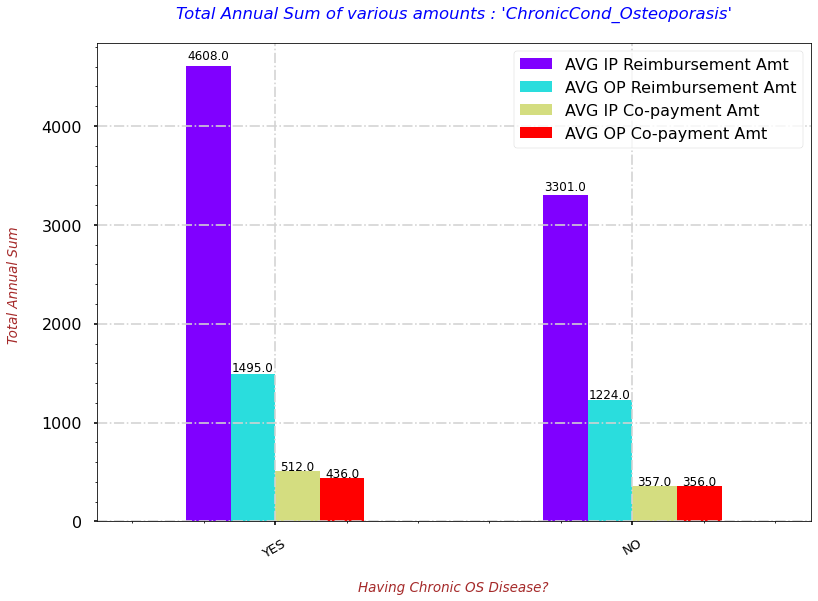

```python
# Here, I'm displaying the Total Annual Sum of IP Co-payment for 'ChronicCond_Osteoporasis'
with plt.style.context('seaborn-poster'):
  fig = CC_OS_all_amts.plot(kind='bar', colormap='rainbow')
  # Using the "patches" function we will get the location of the rectangle bars from the graph.
  ## Then by using those location(width & height) values we will add the annotations
  for p in fig.patches:
    width = p.get_width()
    height = p.get_height()
    x, y = p.get_xy()
    fig.annotate(f'{round(height,0)}', (x + width/2, y + height*1.015), ha='center', fontsize=12, rotation=0)
  # Providing the labels and title to the graph
  plt.xlabel("\nHaving Chronic OS Disease?", fontdict=label_font_dict)
  plt.xticks(ticks=[0,1], labels=['YES', 'NO'], fontsize=13, rotation=30)
  plt.ylabel("Total Annual Sum \n", fontdict=label_font_dict)
  plt.grid(which='major', linestyle="-.", color='lightgrey')
  plt.minorticks_on()
  plt.title("Total Annual Sum of various amounts : 'ChronicCond_Osteoporasis'\n", fontdict=title_font_dict)

# 1 means +ve with Chronic OS Disease
# 2 means -ve with Chronic OS Disease
```

- **`OBSERVATION`**
  - The above graph is telling us below points:
    - Payer pays huge chunk of expenses specially when a beneficiary gets admitted with or without chronic HF disease. To be more precise, in case of +ve the difference is not that high.
    - For other comparisons the difference is not very high.

### **Q18. Lets see the number of beneficiaries on the basis of 'ChronicCond_rheumatoidarthritis'. And, the Annual IP & OP expenditures for such patients.**

```python
# Number of beneficiaries with chronic or no-chronic conditions
pd.DataFrame(train_bene_df.groupby(['ChronicCond_rheumatoidarthritis'])['BeneID'].count())
```

| ChronicCond_rheumatoidarthritis | BeneID |
| --- | --- |
| 1 | 35584 |
| 2 | 102972 |

```python
CC_RH_IP_R = pd.DataFrame(train_bene_df.groupby(['ChronicCond_rheumatoidarthritis'])['IPAnnualReimbursementAmt'].sum() / train_bene_df.groupby(['ChronicCond_rheumatoidarthritis'])['BeneID'].count())
CC_RH_IP_R.columns = ['AVG IP Reimbursement Amt']
CC_RH_IP_R
```

| ChronicCond_rheumatoidarthritis | AVG IP Reimbursement Amt |
| --- | --- |
| 1 | 5102.027597 |
| 2 | 3162.145243 |

```python
CC_RH_OP_R = pd.DataFrame(train_bene_df.groupby(['ChronicCond_rheumatoidarthritis'])['OPAnnualReimbursementAmt'].sum() / train_bene_df.groupby(['ChronicCond_rheumatoidarthritis'])['BeneID'].count())
CC_RH_OP_R.columns = ['AVG OP Reimbursement Amt']
CC_RH_OP_R
```

| ChronicCond_rheumatoidarthritis | AVG OP Reimbursement Amt |
| --- | --- |
| 1 | 1548.057835 |
| 2 | 1211.882745 |

```python
CC_RH_IP_D = pd.DataFrame(train_bene_df.groupby(['ChronicCond_rheumatoidarthritis'])['IPAnnualDeductibleAmt'].sum() / train_bene_df.groupby(['ChronicCond_rheumatoidarthritis'])['BeneID'].count())
CC_RH_IP_D.columns = ['AVG IP Co-payment Amt']
CC_RH_IP_D
```

| ChronicCond_rheumatoidarthritis | AVG IP Co-payment Amt |
| --- | --- |
| 1 | 562.630789 |
| 2 | 343.594259 |

```python
CC_RH_OP_D = pd.DataFrame(train_bene_df.groupby(['ChronicCond_rheumatoidarthritis'])['OPAnnualDeductibleAmt'].sum() / train_bene_df.groupby(['ChronicCond_rheumatoidarthritis'])['BeneID'].count())
CC_RH_OP_D.columns = ['AVG OP Co-payment Amt']
CC_RH_OP_D
```

| ChronicCond_rheumatoidarthritis | AVG OP Co-payment Amt |
| --- | --- |
| 1 | 453.423196 |
| 2 | 351.556928 |

```python
CC_RH_all_amts = pd.concat([CC_RH_IP_R, CC_RH_OP_R, CC_RH_IP_D, CC_RH_OP_D], axis=1)
CC_RH_all_amts
```

| ChronicCond_rheumatoidarthritis | AVG IP Reimbursement Amt | AVG OP Reimbursement Amt | AVG IP Co-payment Amt | AVG OP Co-payment Amt |
| --- | --- | --- | --- | --- |
| 1 | 5102.027597 | 1548.057835 | 562.630789 | 453.423196 |
| 2 | 3162.145243 | 1211.882745 | 343.594259 | 351.556928 |

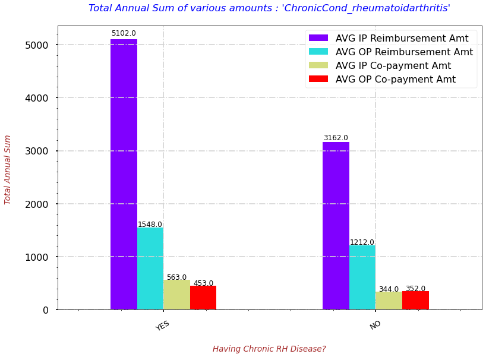

```python
# Here, I'm displaying the Total Annual Sum of IP Co-payment for 'ChronicCond_rheumatoidarthritis'
with plt.style.context('seaborn-poster'):
  fig = CC_RH_all_amts.plot(kind='bar', colormap='rainbow')
  # Using the "patches" function we will get the location of the rectangle bars from the graph.
  ## Then by using those location(width & height) values we will add the annotations
  for p in fig.patches:
    width = p.get_width()
    height = p.get_height()
    x, y = p.get_xy()
    fig.annotate(f'{round(height,0)}', (x + width/2, y + height*1.015), ha='center', fontsize=12, rotation=0)
  # Providing the labels and title to the graph
  plt.xlabel("\nHaving Chronic RH Disease?", fontdict=label_font_dict)
  plt.xticks(ticks=[0,1], labels=['YES', 'NO'], fontsize=13, rotation=30)
  plt.ylabel("Total Annual Sum \n", fontdict=label_font_dict)
  plt.grid(which='major', linestyle="-.", color='lightgrey')
  plt.minorticks_on()
  plt.title("Total Annual Sum of various amounts : 'ChronicCond_rheumatoidarthritis'\n", fontdict=title_font_dict)

# 1 means +ve with Chronic RH Disease
# 2 means -ve with Chronic RH Disease
```

- **`OBSERVATION`**
  - The above graph is telling us below points:
    - Payer pays huge chunk of expenses specially when a beneficiary gets admitted with or without chronic HF disease. To be more precise, in case of +ve the difference is not that high.
    - For other comparisons the difference is not very high.

### **Q19. Lets see the number of beneficiaries on the basis of 'ChronicCond_stroke'. And, the Annual IP & OP expenditures for such patients.**

```python
# Number of beneficiaries with chronic or no-chronic conditions
pd.DataFrame(train_bene_df.groupby(['ChronicCond_stroke'])['BeneID'].count())
```

| ChronicCond_stroke | BeneID |
| --- | --- |
| 1 | 10954 |
| 2 | 127602 |

```python
CC_ST_IP_R = pd.DataFrame(train_bene_df.groupby(['ChronicCond_stroke'])['IPAnnualReimbursementAmt'].sum() / train_bene_df.groupby(['ChronicCond_stroke'])['BeneID'].count())
CC_ST_IP_R.columns = ['AVG IP Reimbursement Amt']
CC_ST_IP_R
```

| ChronicCond_stroke | AVG IP Reimbursement Amt |
| --- | --- |
| 1 | 8111.475260 |
| 2 | 3278.239134 |

```python
CC_ST_OP_R = pd.DataFrame(train_bene_df.groupby(['ChronicCond_stroke'])['OPAnnualReimbursementAmt'].sum() / train_bene_df.groupby(['ChronicCond_stroke'])['BeneID'].count())
CC_ST_OP_R.columns = ['AVG OP Reimbursement Amt']
CC_ST_OP_R
```

| ChronicCond_stroke | AVG OP Reimbursement Amt |
| --- | --- |
| 1 | 1925.197188 |
| 2 | 1244.396404 |

```python
CC_ST_IP_D = pd.DataFrame(train_bene_df.groupby(['ChronicCond_stroke'])['IPAnnualDeductibleAmt'].sum() / train_bene_df.groupby(['ChronicCond_stroke'])['BeneID'].count())
CC_ST_IP_D.columns = ['AVG IP Co-payment Amt']
CC_ST_IP_D
```

| ChronicCond_stroke | AVG IP Co-payment Amt |
| --- | --- |
| 1 | 861.399489 |
| 2 | 360.225326 |

```python
CC_ST_OP_D = pd.DataFrame(train_bene_df.groupby(['ChronicCond_stroke'])['OPAnnualDeductibleAmt'].sum() / train_bene_df.groupby(['ChronicCond_stroke'])['BeneID'].count())
CC_ST_OP_D.columns = ['AVG OP Co-payment Amt']
CC_ST_OP_D
```

| ChronicCond_stroke | AVG OP Co-payment Amt |
| --- | --- |
| 1 | 535.947508 |
| 2 | 364.135061 |

```python
CC_ST_all_amts = pd.concat([CC_ST_IP_R, CC_ST_OP_R, CC_ST_IP_D, CC_ST_OP_D], axis=1)
CC_ST_all_amts
```

| ChronicCond_stroke | AVG IP Reimbursement Amt | AVG OP Reimbursement Amt | AVG IP Co-payment Amt | AVG OP Co-payment Amt |
| --- | --- | --- | --- | --- |
| 1 | 8111.475260 | 1925.197188 | 861.399489 | 535.947508 |
| 2 | 3278.239134 | 1244.396404 | 360.225326 | 364.135061 |

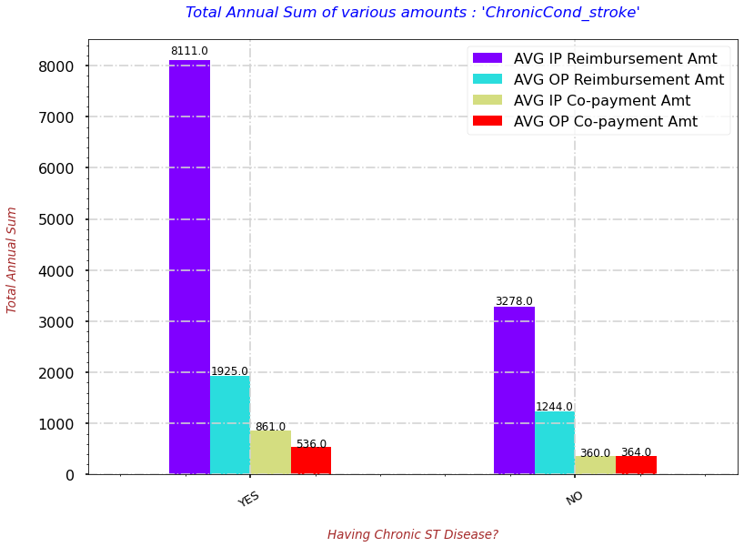

```python
# Here, I'm displaying the Total Annual Sum of IP Co-payment for 'ChronicCond_stroke'
with plt.style.context('seaborn-poster'):
  fig = CC_ST_all_amts.plot(kind='bar', colormap='rainbow')
  # Using the "patches" function we will get the location of the rectangle bars from the graph.
  ## Then by using those location(width & height) values we will add the annotations
  for p in fig.patches:
    width = p.get_width()
    height = p.get_height()
    x, y = p.get_xy()
    fig.annotate(f'{round(height,0)}', (x + width/2, y + height*1.015), ha='center', fontsize=12, rotation=0)
  # Providing the labels and title to the graph
  plt.xlabel("\nHaving Chronic ST Disease?", fontdict=label_font_dict)
  plt.xticks(ticks=[0,1], labels=['YES', 'NO'], fontsize=13, rotation=30)
  plt.ylabel("Total Annual Sum \n", fontdict=label_font_dict)
  plt.grid(which='major', linestyle="-.", color='lightgrey')
  plt.minorticks_on()
  plt.title("Total Annual Sum of various amounts : 'ChronicCond_stroke'\n", fontdict=title_font_dict)

# 1 means +ve with Chronic ST Disease
# 2 means -ve with Chronic ST Disease
```

- **`OBSERVATION`**
  - The above graph is telling us below points:
    - Payer pays huge chunk of expenses specially when a beneficiary gets admitted with or without chronic HF disease. To be more precise, in case of +ve the difference is more than 50%.
    - For other comparisons the difference is not very high.

### **Q20. Lets see the number of beneficiaries on the basis of 'RenalDiseaseIndicator'. And, the Annual IP & OP expenditures for such patients.**

```python
# Number of beneficiaries with chronic or no-chronic conditions
pd.DataFrame(train_bene_df.groupby(['RenalDiseaseIndicator'])['BeneID'].count())
```

| RenalDiseaseIndicator | BeneID |
| --- | --- |
| 0 | 118978 |
| Y | 19578 |

```python
RKD_IP_R = pd.DataFrame(train_bene_df.groupby(['RenalDiseaseIndicator'])['IPAnnualReimbursementAmt'].sum() / train_bene_df.groupby(['RenalDiseaseIndicator'])['BeneID'].count())
RKD_IP_R.columns = ['AVG IP Reimbursement Amt']
RKD_IP_R
```

| RenalDiseaseIndicator | AVG IP Reimbursement Amt |
| --- | --- |
| 0 | 3051.430264 |
| Y | 7360.808050 |

```python
RKD_OP_R = pd.DataFrame(train_bene_df.groupby(['RenalDiseaseIndicator'])['OPAnnualReimbursementAmt'].sum() / train_bene_df.groupby(['RenalDiseaseIndicator'])['BeneID'].count())
RKD_OP_R.columns = ['AVG OP Reimbursement Amt']
RKD_OP_R
```

| RenalDiseaseIndicator | AVG OP Reimbursement Amt |
| --- | --- |
| 0 | 1047.351611 |
| Y | 2822.774543 |

```python
RKD_IP_D = pd.DataFrame(train_bene_df.groupby(['RenalDiseaseIndicator'])['IPAnnualDeductibleAmt'].sum() / train_bene_df.groupby(['RenalDiseaseIndicator'])['BeneID'].count())
RKD_IP_D.columns = ['AVG IP Co-payment Amt']
RKD_IP_D
```

| RenalDiseaseIndicator | AVG IP Co-payment Amt |
| --- | --- |
| 0 | 342.384239 |
| Y | 749.057616 |

```python
RKD_OP_D = pd.DataFrame(train_bene_df.groupby(['RenalDiseaseIndicator'])['OPAnnualDeductibleAmt'].sum() / train_bene_df.groupby(['RenalDiseaseIndicator'])['BeneID'].count())
RKD_OP_D.columns = ['AVG OP Co-payment Amt']
RKD_OP_D
```

| RenalDiseaseIndicator | AVG OP Co-payment Amt |
| --- | --- |
| 0 | 311.659139 |
| Y | 779.167944 |

```python
RKD_all_amts = pd.concat([RKD_IP_R, RKD_OP_R, RKD_IP_D, RKD_OP_D], axis=1)
RKD_all_amts
```

| RenalDiseaseIndicator | AVG IP Reimbursement Amt | AVG OP Reimbursement Amt | AVG IP Co-payment Amt | AVG OP Co-payment Amt |
| --- | --- | --- | --- | --- |
| 0 | 3051.430264 | 1047.351611 | 342.384239 | 311.659139 |
| Y | 7360.808050 | 2822.774543 | 749.057616 | 779.167944 |

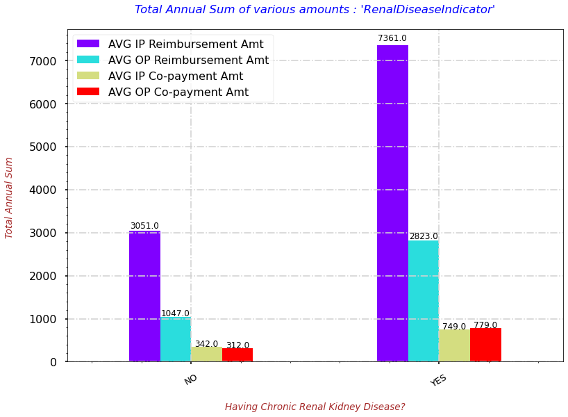

```python
# Here, I'm displaying the Total Annual Sum of IP Co-payment for 'RenalDiseaseIndicator'
with plt.style.context('seaborn-poster'):
  fig = RKD_all_amts.plot(kind='bar', colormap='rainbow')
  # Using the "patches" function we will get the location of the rectangle bars from the graph.
  ## Then by using those location(width & height) values we will add the annotations
  for p in fig.patches:
    width = p.get_width()
    height = p.get_height()
    x, y = p.get_xy()
    fig.annotate(f'{round(height,0)}', (x + width/2, y + height*1.015), ha='center', fontsize=12, rotation=0)
  # Providing the labels and title to the graph
  plt.xlabel("\nHaving Chronic Renal Kidney Disease?", fontdict=label_font_dict)
  plt.xticks(ticks=[0,1], labels=['NO', 'YES'], fontsize=13, rotation=30)
  plt.ylabel("Total Annual Sum \n", fontdict=label_font_dict)
  plt.grid(which='major', linestyle="-.", color='lightgrey')
  plt.minorticks_on()
  plt.title("Total Annual Sum of various amounts : 'RenalDiseaseIndicator'\n", fontdict=title_font_dict)

# Y means +ve with Renal Kidney Disease
# 0 means -ve with Renal Kidney Disease
```

### **Q21. Lets check the percentiles of the pre-disease indicators for the Annual IP expenditures for such patients.**

```python
def cal_display_percentiles(x_col, y_col, title_lbl, x_filter_code):
    """
    Description : This function is created for calculating and generating the percentiles for pre-disease indicators.

    Input: It accepts below parameters:
        1. x_col : Disease indicator feature name.
        2. y_col : Feature like re-imbursement or deductible amount whose percentiles you want to generate.
        3. title_lbl : Label to be provided in the title of the plot.
        4. x_filter_code : Category code for which you want to generate the percentiles.

    Output: It returns the dataframe having percentiles and their respective values for the specific disease indicator feature.
    And, it displays the pointplot graph of the same.
    """
    percentiles = []
    percentiles_vals = []

    # Calculating & storing the various percentiles and their respective values
    for val in [0.1,0.2,0.25,0.3,0.4,0.5,0.6,0.7,0.75,0.8,0.9,0.91,0.92,0.93,0.94,0.95,0.96,0.97,0.98,0.99,0.999,0.9999,0.99999,0.999999,1.0]:
        percentile = round(float(val*100),6)
        percentiles.append(percentile)

        percentile_val = round(train_bene_df[train_bene_df[x_col] == x_filter_code][y_col].quantile(val),1)
        percentiles_vals.append(percentile_val)

    # Creating the temp dataframe for displaying the results
    tmp_percentiles = pd.DataFrame([percentiles, percentiles_vals]).T
    tmp_percentiles.columns = ['Percentiles', 'Values']

    # Here, I'm displaying the Percentiles values for all disease code features
    with plt.style.context('seaborn-poster'):
        plt.figure(figsize=(15,7))
        sns.pointplot(data=tmp_percentiles, x='Percentiles', y='Values', markers="o", palette='spring')
        sns.pointplot(data=tmp_percentiles, x='Percentiles', y='Values', markers="", color='grey', linestyles="solid")
        # Providing the labels and title to the graph
        plt.xlabel("\nPercentiles", fontdict=label_font_dict)
        plt.xticks(rotation=90, size=12)
        plt.ylabel("Total Annual `{}` Sum \n".format(y_col), fontdict=label_font_dict)
        plt.grid(which='major', linestyle="-.", color='lightpink')
        plt.minorticks_on()
        plt.title("Percentile values of `{}` :: `{}`\n".format(y_col,title_lbl), fontdict=title_font_dict)

    return tmp_percentiles
```

- **(RenalDiseaseIndicator == YES) and (IPAnnualReimbursementAmt)**

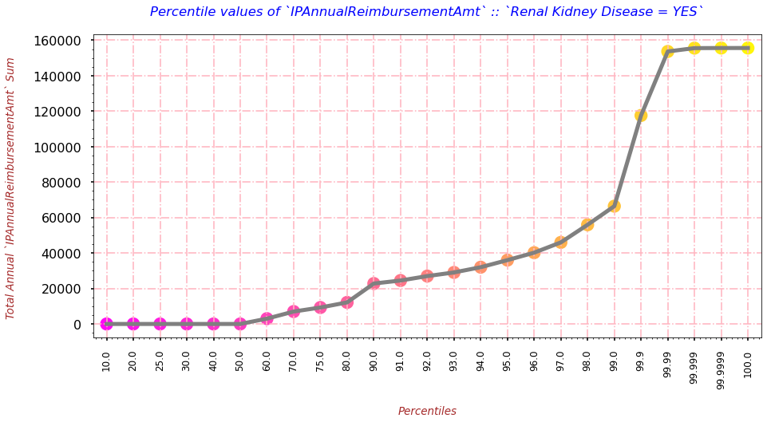

```python
RKD_YES_IP_R_percentiles = cal_display_percentiles(x_col='RenalDiseaseIndicator',
                                                   y_col='IPAnnualReimbursementAmt',
                                                   title_lbl="Renal Kidney Disease = YES",
                                                   x_filter_code='Y')
```

- **`OBSERVATION`**
  - The above graph shows us that some of the reimbursements paid by the PAYER are very high as compared to the rest of the records.
    - This can be a potential sign of fraudulent cases because generally the criminals file some forge cases with exponentially high amounts.
- **(RenalDiseaseIndicator == NO) and (IPAnnualReimbursementAmt)**

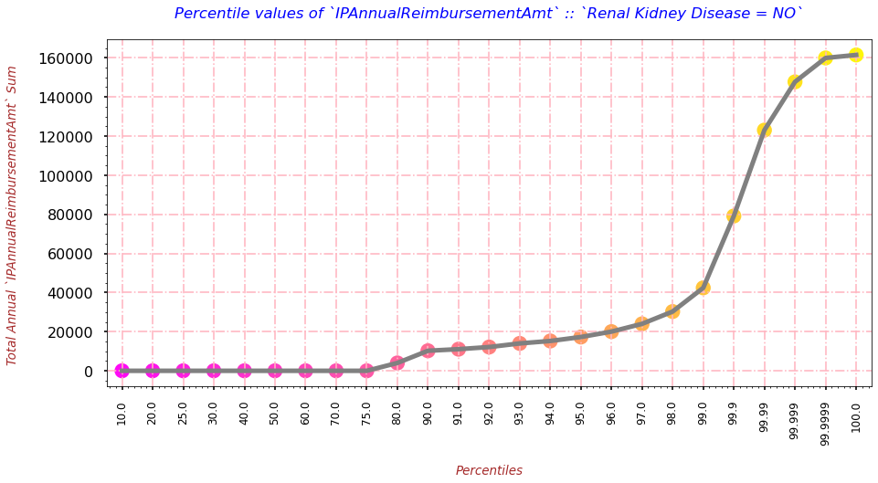

```python
RKD_NO_IP_R_percentiles = cal_display_percentiles(x_col='RenalDiseaseIndicator',
                                                   y_col='IPAnnualReimbursementAmt',
                                                   title_lbl="Renal Kidney Disease = NO",
                                                   x_filter_code='0')
```

- **`OBSERVATION`**
  - The above graph shows us that some of the reimbursements paid by the PAYER are very high as compared to the rest of the records.
    - This can be a potential sign of fraudulent cases because generally the criminals file some forge cases with exponentially high amounts.
- **(RenalDiseaseIndicator == YES) and (OPAnnualReimbursementAmt)**

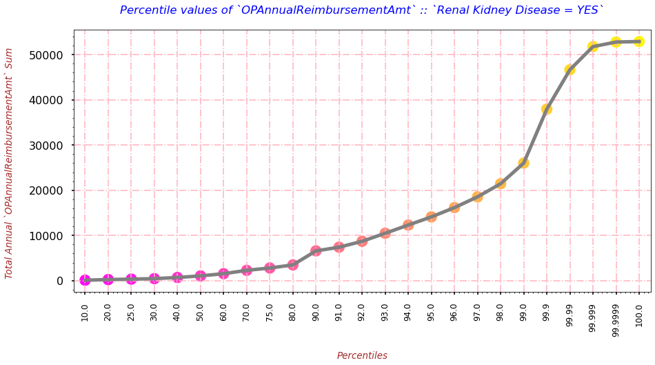

```python
RKD_YES_OP_R_percentiles = cal_display_percentiles(x_col='RenalDiseaseIndicator',
                                                   y_col='OPAnnualReimbursementAmt',
                                                   title_lbl="Renal Kidney Disease = YES",
                                                   x_filter_code='Y')
```

- **`OBSERVATION`**
  - The above graph shows us that some of the reimbursements paid by the PAYER are very high as compared to the rest of the records.
    - This can be a potential sign of fraudulent cases because generally the criminals file some forge cases with exponentially high amounts.
- **(RenalDiseaseIndicator == NO) and (OPAnnualReimbursementAmt)**

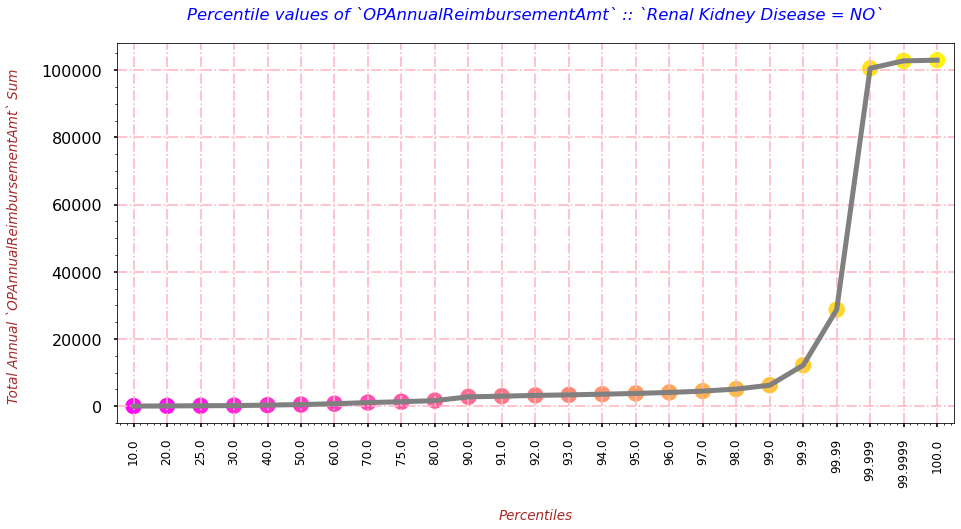

```python
RKD_NO_OP_R_percentiles = cal_display_percentiles(x_col='RenalDiseaseIndicator',
                                                   y_col='OPAnnualReimbursementAmt',
                                                   title_lbl="Renal Kidney Disease = NO",
                                                   x_filter_code='0')
```

- **`OBSERVATION`**
  - The above graph shows us that some of the reimbursements paid by the PAYER are very high as compared to the rest of the records.
    - This can be a potential sign of fraudulent cases because generally the criminals file some forge cases with exponentially high amounts.
- **(ChronicCond_stroke == YES) and (IPAnnualReimbursementAmt)**

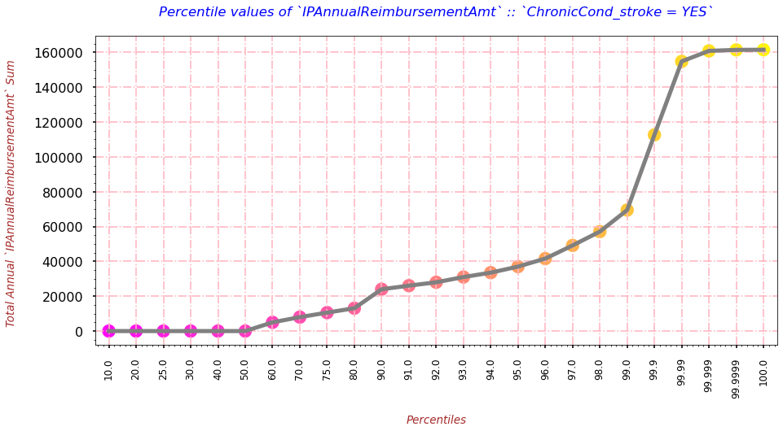

```python
CC_ST_YES_IP_R_percentiles = cal_display_percentiles(x_col='ChronicCond_stroke',
                                                     y_col='IPAnnualReimbursementAmt',
                                                     title_lbl="ChronicCond_stroke = YES",
                                                     x_filter_code=1)
```

- **`OBSERVATION`**
  - The above graph shows us that some of the reimbursements paid by the PAYER are very high as compared to the rest of the records.
    - This can be a potential sign of fraudulent cases because generally the criminals file some forge cases with exponentially high amounts.
- **(ChronicCond_stroke == NO) and (IPAnnualReimbursementAmt)**

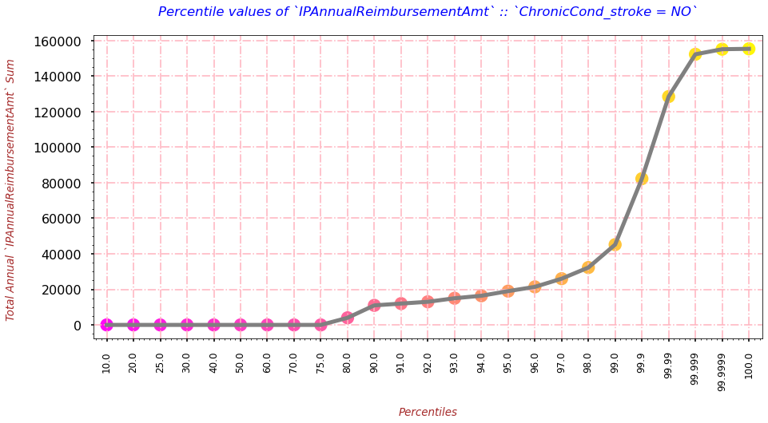

```python
CC_ST_NO_IP_R_percentiles = cal_display_percentiles(x_col='ChronicCond_stroke',
                                                     y_col='IPAnnualReimbursementAmt',
                                                     title_lbl="ChronicCond_stroke = NO",
                                                     x_filter_code=2)
```

- **`OBSERVATION`**
  - The above graph shows us that some of the reimbursements paid by the PAYER are very high as compared to the rest of the records.
    - This can be a potential sign of fraudulent cases because generally the criminals file some forge cases with exponentially high amounts.
- **(ChronicCond_stroke == YES) and (OPAnnualReimbursementAmt)**

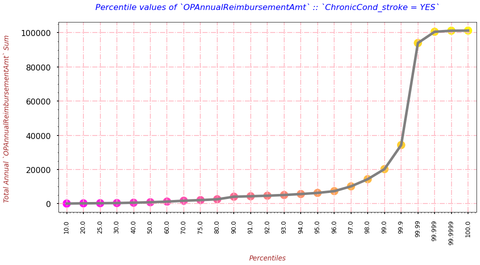

```python
CC_ST_YES_OP_R_percentiles = cal_display_percentiles(x_col='ChronicCond_stroke',
                                                     y_col='OPAnnualReimbursementAmt',
                                                     title_lbl="ChronicCond_stroke = YES",
                                                     x_filter_code=1)
```

- **`OBSERVATION`**
  - The above graph shows us that some of the reimbursements paid by the PAYER are very high as compared to the rest of the records.
    - This can be a potential sign of fraudulent cases because generally the criminals file some forge cases with exponentially high amounts.
- **(ChronicCond_stroke == NO) and (OPAnnualReimbursementAmt)**

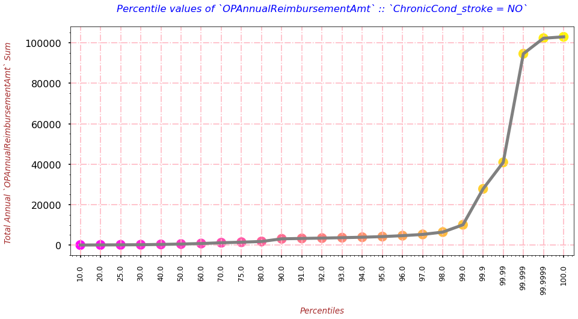

```python
CC_ST_NO_OP_R_percentiles = cal_display_percentiles(x_col='ChronicCond_stroke',
                                                     y_col='OPAnnualReimbursementAmt',
                                                     title_lbl="ChronicCond_stroke = NO",
                                                     x_filter_code=2)
```

- **`OBSERVATION`**
  - The above graph shows us that some of the reimbursements paid by the PAYER are very high as compared to the rest of the records.
    - This can be a potential sign of fraudulent cases because generally the criminals file some forge cases with exponentially high amounts.

### **Q22. Lets just visualize the spread of pre-disease indicators for the Annual IP and OP expenditures across males and females.**

```python
def plot_strip_plots(x_col, hue_col, y_col, lgd_title):
    """
    Description : This function is created for plotting the spread of data points of pre-disease indicators for the Annual IP and OP expenditures
    across males and females.

    Input: It accepts below parameters:
        1. x_col : Gender feature.
        2. hue_Col : Pre-Disease indicator
        3. y_col : Feature like re-imbursement or deductible amount whose percentiles you want to generate.
        4. lgd_title : Category code for which you want to generate the data spread.

    Output: It displays the stipplot graph of the same.
    """
    with plt.style.context('seaborn-poster'):
        plt.figure(figsize=(10,7))
        sns.stripplot(data=train_bene_df, x=x_col, y=y_col, hue=hue_col, palette='plasma')
        # Providing the labels and title to the graph
        plt.xlabel("\n{}".format(x_col), fontdict=label_font_dict)
        plt.xticks(rotation=90, size=12)
        plt.ylabel("{}\n".format(y_col), fontdict=label_font_dict)
        plt.grid(which='major', linestyle="-.", color='lightpink')
        plt.minorticks_on()
        plt.title("Spread of payment paid by payer\n", fontdict=title_font_dict)
        plt.legend(loc='upper center',title=lgd_title)
```

- **(RenalDiseaseIndicator) , (IPAnnualReimbursementAmt) and (GENDER)**

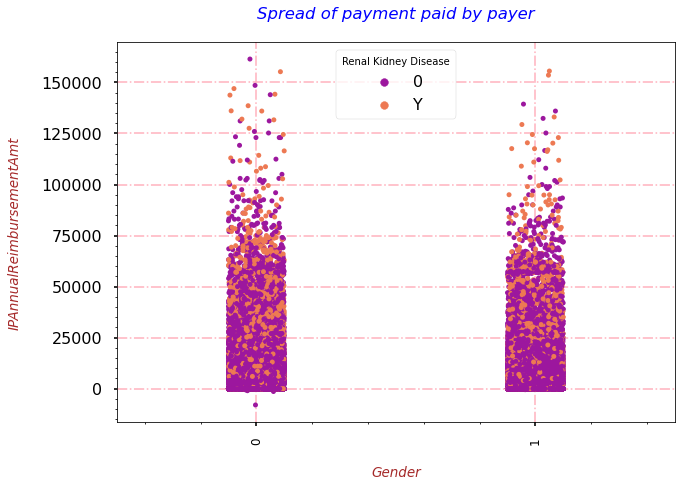

```python
plot_strip_plots(x_col='Gender', hue_col="RenalDiseaseIndicator", y_col='IPAnnualReimbursementAmt', lgd_title="Renal Kidney Disease")
```

- **`OBSERVATION`**
  - The above graph shows us the complete overlapping of data points with some potential outliers(may be fraud).
    - Here, another thing that I found is that few of the points lying in the negative range(this is quite strange may be error).

```python
train_bene_df['OPAnnualReimbursementAmt'].min(), train_bene_df['IPAnnualReimbursementAmt'].min()
```

```
(-70, -8000)
```

```python
train_bene_df['OPAnnualDeductibleAmt'].min(), train_bene_df['IPAnnualDeductibleAmt'].min()
```

```
(0, 0)
```

- **(RenalDiseaseIndicator) , (OPAnnualReimbursementAmt) and (GENDER)**

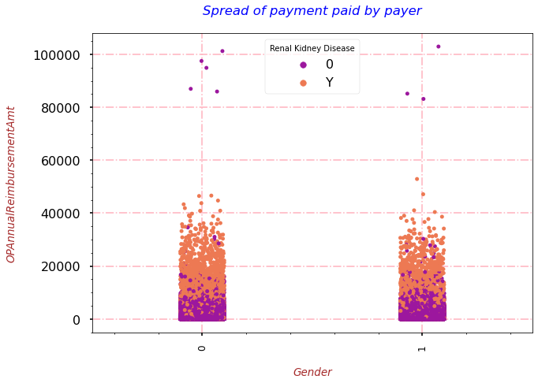

```python
plot_strip_plots(x_col='Gender', hue_col="RenalDiseaseIndicator", y_col='OPAnnualReimbursementAmt', lgd_title="Renal Kidney Disease")
```

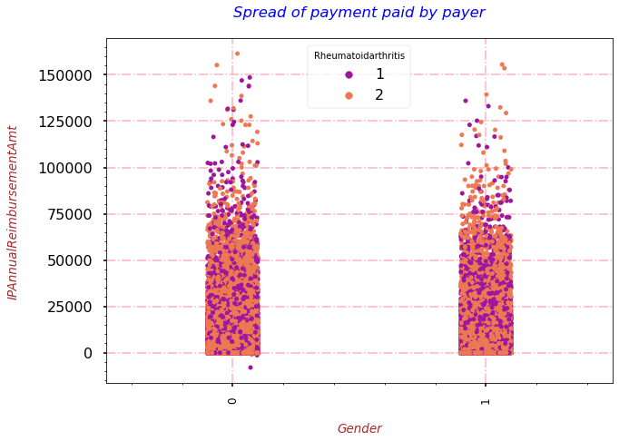

```python
plot_strip_plots(x_col='Gender', hue_col="ChronicCond_rheumatoidarthritis", y_col='IPAnnualReimbursementAmt', lgd_title="Rheumatoidarthritis")
```

- **`OBSERVATION`**
  - The above graph shows us the complete overlapping of data points with some potential outliers(may be fraud).
    - Here, another thing taht I found is that few of the points lying in the negative range(this is quite strange may be error).
- **(ChronicCond_rheumatoidarthritis) , (OPAnnualReimbursementAmt) and (GENDER)**

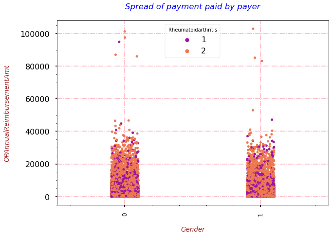

```python
plot_strip_plots(x_col='Gender', hue_col="ChronicCond_rheumatoidarthritis", y_col='OPAnnualReimbursementAmt', lgd_title="Rheumatoidarthritis")
```

- **`OBSERVATION`**
  - The above graph shows us the complete overlapping of data points with some potential outliers(may be fraud).
    - Here, another thing taht I found is that few of the points lying in the negative range(this is quite strange may be error).
- **(ChronicCond_IschemicHeart) , (IPAnnualReimbursementAmt) and (GENDER)**

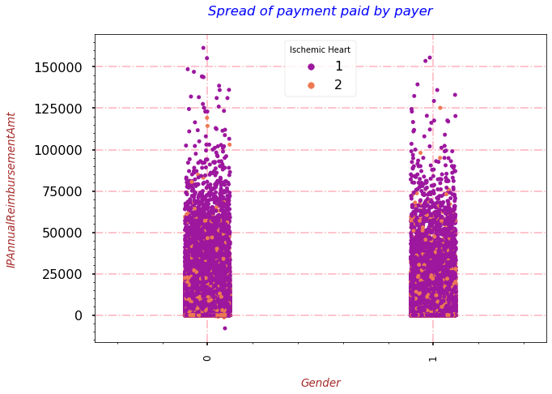

```python
plot_strip_plots(x_col='Gender', hue_col="ChronicCond_IschemicHeart", y_col='IPAnnualReimbursementAmt', lgd_title="Ischemic Heart")
```

- **`OBSERVATION`**
  - The above graph shows us the complete overlapping of data points with some potential outliers specifically for patients with Chronic Heart Desiase(may be fraud).
    - Here, another thing taht I found is that few of the points lying in the negative range(this is quite strange may be error).
- **(ChronicCond_IschemicHeart) , (OPAnnualReimbursementAmt) and (GENDER)**

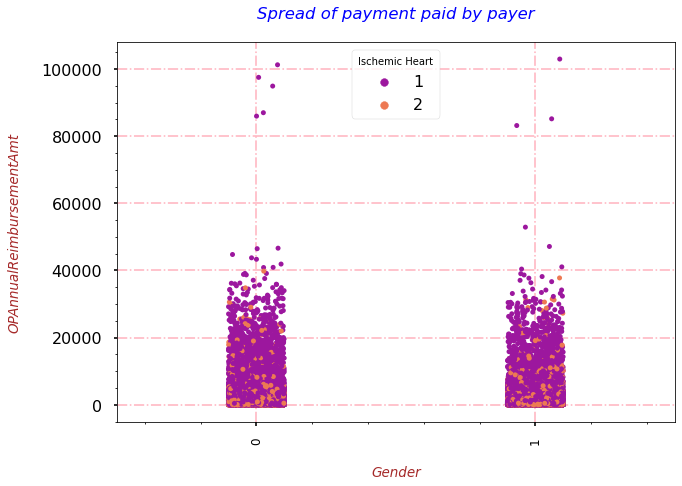

```python
plot_strip_plots(x_col='Gender', hue_col="ChronicCond_IschemicHeart", y_col='OPAnnualReimbursementAmt', lgd_title="Ischemic Heart")
```

- **`OBSERVATION`**
  - The above graph shows us the complete overlapping of data points with some potential outliers specifically for patients with Chronic Heart Desiase(may be fraud).
    - Here, another thing taht I found is that few of the points lying in the negative range(this is quite strange may be error).

### **Q23. Lets visualize the spread of Annual IP and OP expenditures through out the AGE and its assciated features for males and females.**

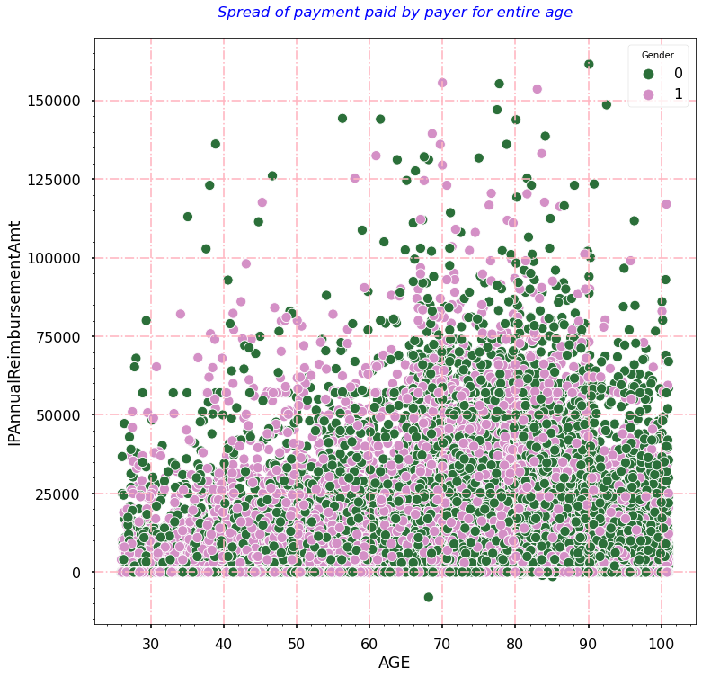

```python
with plt.style.context('seaborn-poster'):
    plt.figure(figsize=(12,12))
    sns.scatterplot(data=train_bene_df, x='AGE', y='IPAnnualReimbursementAmt', hue='Gender', palette='cubehelix')
    plt.grid(which='major', linestyle="-.", color='lightpink')
    plt.minorticks_on()
    plt.title("Spread of payment paid by payer for entire age\n", fontdict=title_font_dict)
```

- **`OBSERVATION`**
  - The above graph shows us the complete overlapping of data points.

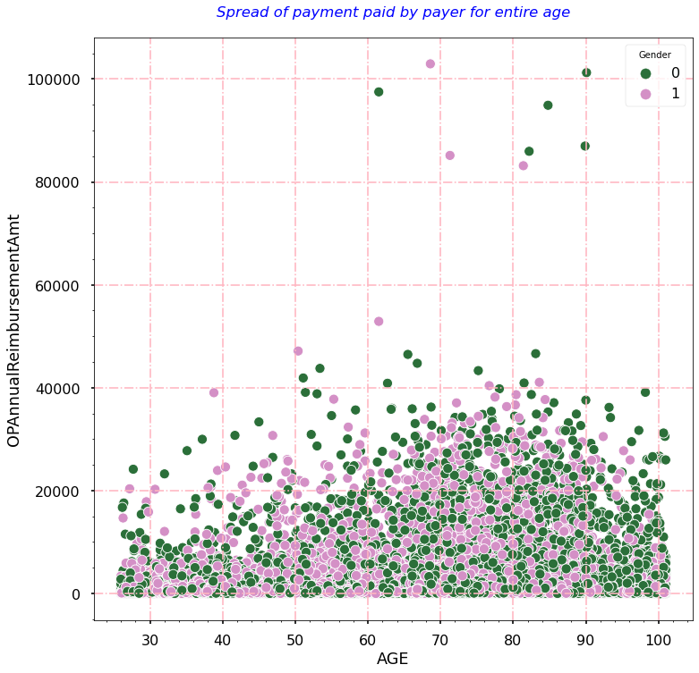

```python
with plt.style.context('seaborn-poster'):
    plt.figure(figsize=(12,12))
    sns.scatterplot(data=train_bene_df, x='AGE', y='OPAnnualReimbursementAmt', hue='Gender', palette='cubehelix')
    plt.grid(which='major', linestyle="-.", color='lightpink')
    plt.minorticks_on()
    plt.title("Spread of payment paid by payer for entire age\n", fontdict=title_font_dict)
```

- **`OBSERVATION`**
  - The above graph shows us the complete overlapping of data points.
- **(AGE GROUPS) , (IPAnnualReimbursementAmt) and (GENDER)**

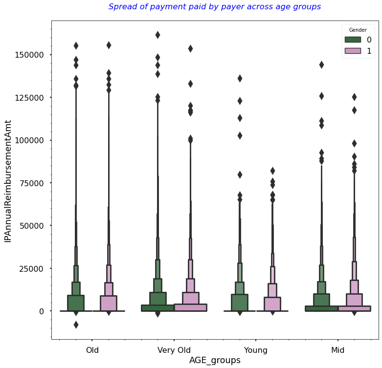

```python
with plt.style.context('seaborn-poster'):
    plt.figure(figsize=(12,12))
    sns.boxenplot(data=train_bene_df, x='AGE_groups', y='IPAnnualReimbursementAmt', hue='Gender', palette='cubehelix')
    plt.minorticks_on()
    plt.title("Spread of payment paid by payer across age groups\n", fontdict=title_font_dict)
```

- **`OBSERVATION`**
  - The above graph shows us there is no such difference in the amounts across different AGE Groups.
- **(AGE GROUPS) , (OPAnnualReimbursementAmt) and (GENDER)**

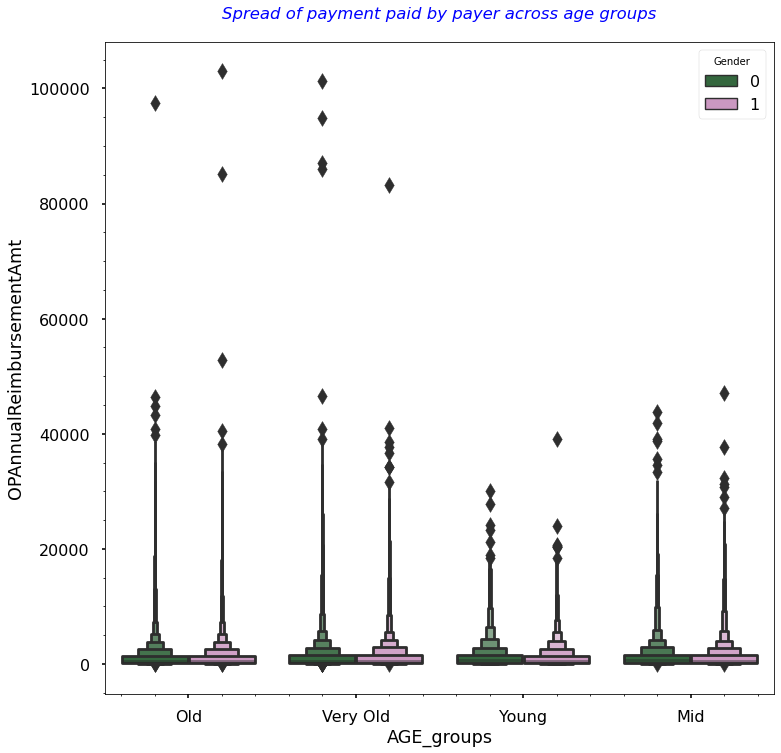

```python
with plt.style.context('seaborn-poster'):
    plt.figure(figsize=(12,12))
    sns.boxenplot(data=train_bene_df, x='AGE_groups', y='OPAnnualReimbursementAmt', hue='Gender', palette='cubehelix')
    plt.minorticks_on()
    plt.title("Spread of payment paid by payer across age groups\n", fontdict=title_font_dict)
```

- **`OBSERVATION`**
  - The above graph shows us there is no such difference in the amounts across different AGE Groups.
- **(DOB MONTH) , (IPAnnualReimbursementAmt) and (GENDER)**

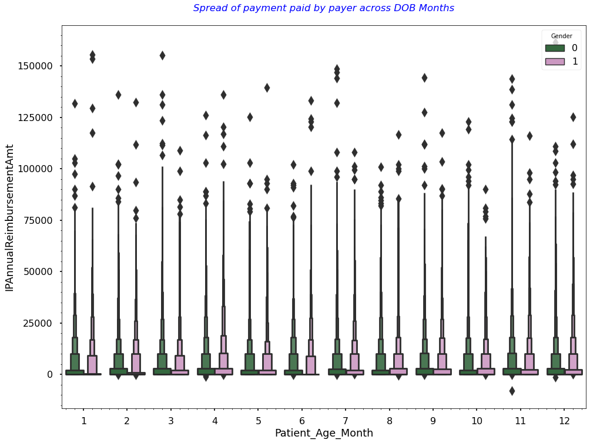

```python
with plt.style.context('seaborn-poster'):
    plt.figure(figsize=(16,12))
    sns.boxenplot(data=train_bene_df, x='Patient_Age_Month', y='IPAnnualReimbursementAmt', hue='Gender', palette='cubehelix')
    plt.minorticks_on()
    plt.title("Spread of payment paid by payer across DOB Months\n", fontdict=title_font_dict)
    plt.legend(loc='upper right', title="Gender")
```

- **`OBSERVATION`**
  - The above graph shows us there is no such difference in the amounts across different AGE Groups.
- **(DOB MONTH) , (OPAnnualReimbursementAmt) and (GENDER)**

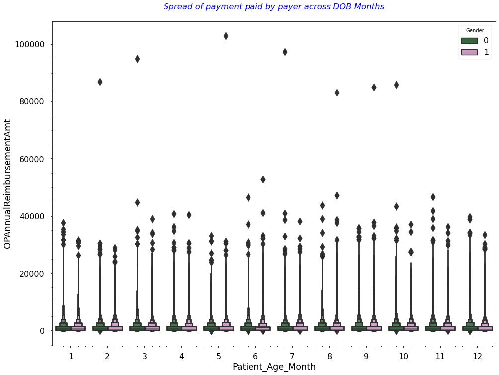

```python
with plt.style.context('seaborn-poster'):
    plt.figure(figsize=(16,12))
    sns.boxenplot(data=train_bene_df, x='Patient_Age_Month', y='OPAnnualReimbursementAmt', hue='Gender', palette='cubehelix')
    plt.minorticks_on()
    plt.title("Spread of payment paid by payer across DOB Months\n", fontdict=title_font_dict)
    plt.legend(loc='upper right', title="Gender")
```

- **`OBSERVATION`**
  - The above graph shows us there is no such difference in the amounts across different AGE Groups.
- **(DOB YEARS) , (IPAnnualReimbursementAmt) and (GENDER)**

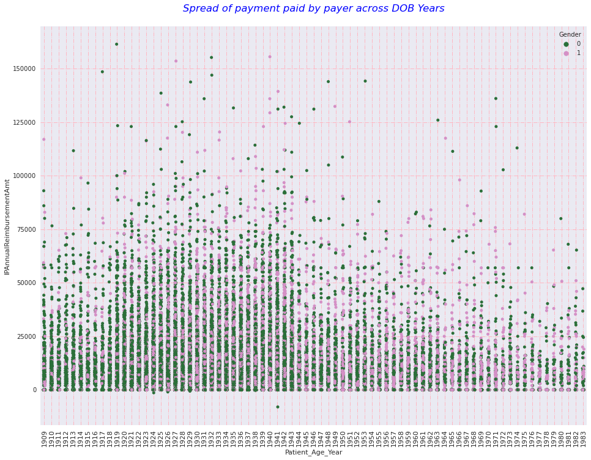

```python
with plt.style.context('seaborn'):
    plt.figure(figsize=(16,12))
    sns.stripplot(data=train_bene_df, x='Patient_Age_Year', y='IPAnnualReimbursementAmt', hue='Gender', palette='cubehelix')
    plt.xticks(rotation=90, fontsize=11)
    plt.grid(which='major', linestyle="-.", color='lightpink')
    plt.minorticks_on()
    plt.title("Spread of payment paid by payer across DOB Years\n", fontdict=title_font_dict)
```

- **`OBSERVATION`**
  - The above graph shows us there is no such difference in the amounts across different AGE Groups.
- **(DOB YEARS) , (OPAnnualReimbursementAmt) and (GENDER)**

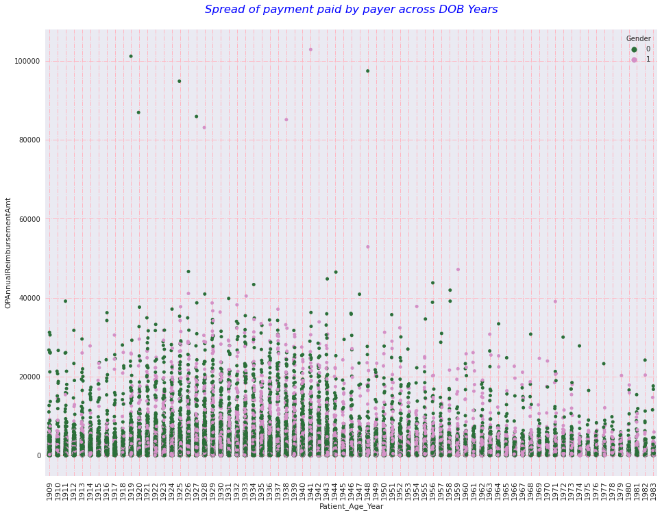

```python
with plt.style.context('seaborn'):
    plt.figure(figsize=(16,12))
    sns.stripplot(data=train_bene_df, x='Patient_Age_Year', y='OPAnnualReimbursementAmt', hue='Gender', palette='cubehelix')
    plt.xticks(rotation=90, fontsize=11)
    plt.grid(which='major', linestyle="-.", color='lightpink')
    plt.minorticks_on()
    plt.title("Spread of payment paid by payer across DOB Years\n", fontdict=title_font_dict)
```

- **`OBSERVATION`**
  - The above graph shows us there is no such difference in the amounts across different AGE Groups.
- **(LIFE Status) , (IPAnnualReimbursementAmt) and (GENDER)**

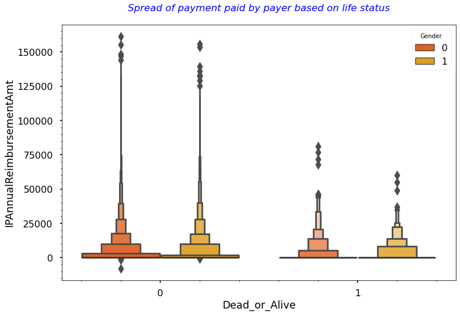

```python
with plt.style.context('seaborn-poster'):
    plt.figure(figsize=(12,8))
    sns.boxenplot(data=train_bene_df, x='Dead_or_Alive', y='IPAnnualReimbursementAmt', hue='Gender', palette='autumn')
    plt.minorticks_on()
    plt.title("Spread of payment paid by payer based on life status\n", fontdict=title_font_dict)
```

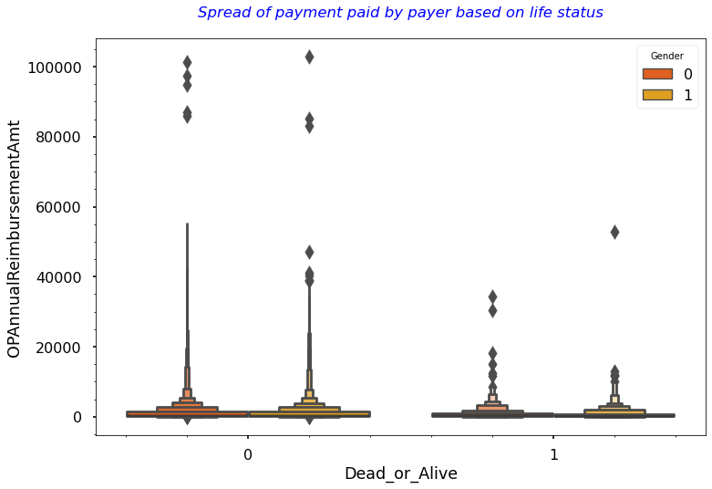

```python
with plt.style.context('seaborn-poster'):
    plt.figure(figsize=(12,8))
    sns.boxenplot(data=train_bene_df, x='Dead_or_Alive', y='OPAnnualReimbursementAmt', hue='Gender', palette='autumn')
    plt.minorticks_on()
    plt.title("Spread of payment paid by payer based on life status\n", fontdict=title_font_dict)
```

- **`OBSERVATION`**
  - The above graph shows us there is no such difference in the amounts across different AGE Groups.
- **(HUMAN RACE) , (IPAnnualReimbursementAmt) and (GENDER)**

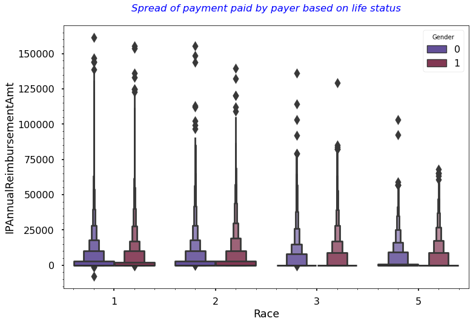

```python
with plt.style.context('seaborn-poster'):
    plt.figure(figsize=(12,8))
    sns.boxenplot(data=train_bene_df, x='Race', y='IPAnnualReimbursementAmt', hue='Gender', palette='twilight')
    plt.minorticks_on()
    plt.title("Spread of payment paid by payer based on life status\n", fontdict=title_font_dict)
```

- **`OBSERVATION`**
  - The above graph shows us there is no such difference in the amounts across different AGE Groups.
- **(HUMAN RACE) , (OPAnnualReimbursementAmt) and (GENDER)**

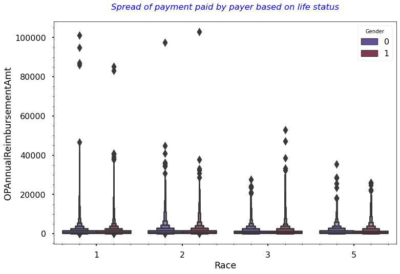

```python
with plt.style.context('seaborn-poster'):
    plt.figure(figsize=(12,8))
    sns.boxenplot(data=train_bene_df, x='Race', y='OPAnnualReimbursementAmt', hue='Gender', palette='twilight')
    plt.minorticks_on()
    plt.title("Spread of payment paid by payer based on life status\n", fontdict=title_font_dict)
```

- **`OBSERVATION`**
  - The above graph shows us there is no such difference in the amounts across different AGE Groups.

## **`SUMMARY`**

1. For the below mentioned features, based on the above initial analysis it looks like these might not be able to provide much information or differentiation but still I would like to check them after adding CLAIMS data.
   - `DOB YEAR`
   - `DOB MONTH`
   - `AGE GROUPS`
   - `LIFE STATUS`
   - `HUMAN RACE`
   - `STATE`
1. For the below mentioned features majority of the values are same which most probably won't be of any use thus removing these from BENE dataset.
   - `NoOfMonths_PartACov`
   - `NoOfMonths_PartBCov`
1. The `Pre-disease` indicators looks like important features based on the initial analysis thus it would interesting to see how much they are useful after adding CLAIMS dataset.
1. `Date of Death` is also removed from the dataset, as we have already calculated bene age, life status and others out of it.

```python
train_bene_df.drop(["NoOfMonths_PartACov", "NoOfMonths_PartBCov"], axis=1, inplace=True)
```

```python
train_bene_df.shape
```

```
(138556, 27)
```

```python
train_bene_df.head()
```

|  | BeneID | DOB | Gender | Race | RenalDiseaseIndicator | State | County | ChronicCond_Alzheimer | ChronicCond_Heartfailure | ChronicCond_KidneyDisease | ChronicCond_Cancer | ChronicCond_ObstrPulmonary | ChronicCond_Depression | ChronicCond_Diabetes | ChronicCond_IschemicHeart | ChronicCond_Osteoporasis | ChronicCond_rheumatoidarthritis | ChronicCond_stroke | IPAnnualReimbursementAmt | IPAnnualDeductibleAmt | OPAnnualReimbursementAmt | OPAnnualDeductibleAmt | Patient_Age_Year | Patient_Age_Month | Dead_or_Alive | AGE | AGE_groups |
| --- | --- | --- | --- | --- | --- | --- | --- | --- | --- | --- | --- | --- | --- | --- | --- | --- | --- | --- | --- | --- | --- | --- | --- | --- | --- | --- | --- |
| 0 | BENE11001 | 1943-01-01 | 1 | 1 | 0 | 39 | 230 | 1 | 2 | 1 | 2 | 2 | 1 | 1 | 1 | 2 | 1 | 1 | 36000 | 3204 | 60 | 70 | 1943 | 1 | 0 | 67.0 | Old |
| 1 | BENE11002 | 1936-09-01 | 0 | 1 | 0 | 39 | 280 | 2 | 2 | 2 | 2 | 2 | 2 | 2 | 2 | 2 | 2 | 2 | 0 | 0 | 30 | 50 | 1936 | 9 | 0 | 73.3 | Old |
| 2 | BENE11003 | 1936-08-01 | 1 | 1 | 0 | 52 | 590 | 1 | 2 | 2 | 2 | 2 | 2 | 2 | 1 | 2 | 2 | 2 | 0 | 0 | 90 | 40 | 1936 | 8 | 0 | 73.4 | Old |
| 3 | BENE11004 | 1922-07-01 | 1 | 1 | 0 | 39 | 270 | 1 | 1 | 2 | 2 | 2 | 2 | 1 | 1 | 1 | 1 | 2 | 0 | 0 | 1810 | 760 | 1922 | 7 | 0 | 87.5 | Very Old |
| 4 | BENE11005 | 1935-09-01 | 1 | 1 | 0 | 24 | 680 | 2 | 2 | 2 | 2 | 1 | 2 | 1 | 2 | 2 | 2 | 2 | 0 | 0 | 1790 | 1200 | 1935 | 9 | 0 | 74.3 | Old |

```python
train_bene_df.to_csv("train_bene_1.csv")
```